# Sim vs Obs for Bronwyn Masters’ Silkwood experiment on a Bulgun soil

Bianca Das & Jody Biggs

13 March, 2018

# 1 Experiment details

## 1.1 Site

- Silkwood, South Johnstone sub-basin
- (17<sup>o</sup>44’44.72“S; 146<sup>o</sup>2’58.76”E)
- Bingal Bay BOM station #032009

## 1.2 Treatments

- Urea unless otherwise indicated
- Unreplicated

```r
treatDesc <-
  read.csv('./Measurements/TreatmentDescription.csv', stringsAsFactors = FALSE) %>%
  mutate(ratoon_no = as.character(ratoon_no))
kable(treatDesc)
```

| ratoon_no | treatCode | fertN_kg_ha | fertType | ureaPerc | crfPerc |
| --- | --- | --- | --- | --- | --- |
| 0 | T1 | 194 | urea | 100 | 0 |
| 0 | T2 | 134 | urea | 100 | 0 |
| 0 | T3 | 94 | urea | 100 | 0 |
| 0 | T4 | 94 | crfblend | 33 | 66 |
| 0 | T5 | 67 | urea | 100 | 0 |
| 1 | T1 | 190 | urea | 100 | 0 |
| 1 | T2 | 158 | urea | 100 | 0 |
| 1 | T3 | 112 | urea | 100 | 0 |
| 1 | T4 | 110 | crfblend | 53 | 47 |
| 1 | T5 | 0 | urea | 100 | 0 |

## 1.3 Measurements

- Above-ground biomass was measured but the values are not in the report
- Water quality data collected from T1-T4 only

### 1.3.1 N loss

- Total off-site N loss ranged from 19-112 kgN/ha
- Plant crop NinRO = 6-11 kgN/ha
- Ratoon crop NinRO = 8-12 kgN/ha
- Plant crop runoff 8% of rainfall
- Ratoon crop runoff 48% of rainfall
- Plant crop drainage 31% of rainfall
- Ratoon crop drainage 22% of rainfall
- Unaccounted for N was considered to be primarily gas loss (via denit and volat)

## 1.4 Crop management

- Q183 variety
- 2014-05-28: Preliminary nutrients soil sampling
- 2014-07-21: Nutrients soil sampling (prior to planting)
- 2014-07-21: planted 2014-07-21
- 2014-07-21: at planting DAP 22.5 kgN/ha + 7 kgN/ha in liquid form
- 2014-10-22: N fertiliser top-dressed and lightly cultivated (3month later; check date is not 2014-10-02)
- 2015-11-11: harvest (gctb); soil sampling to 90cm
- 2015-11-25: N fertiliser applied via stool-split
- 2016-11-25: ratoon crop harvest
- 2016-11-28: soil sampling to 90cm (after harvest)
- T1 plant crop impacted by lodging and subsequent suckering (image taken 2015-03-08)
- Two metre spaced beds with dual cane rows 70cm apart
- Cultivation and weed mgt same across treatments

## 1.5 Paddock history:

- previous sugarcane yields at the paddock were 35-72 t/ha
- laser-leveled in 2013 (following harvest)
- sprayed out bare fallow for 2013-2014 season
- further cultivation after wet season

## 1.6 Soil:

- Hydrosol / Bulgun soil
- Hydrosol is a soil that experiences saturation of the greater part of the profile for prolonged periods in most years.
- low permeability
- low elevation
- high propotion of runoff
- saturated for long periods of time
- water table remaining within 60cm for days to weeks after substantial rainfall
- pH 5.1 and OC 5.7 % in top 10 cm

## 1.8 Bianca

bare fallow period 2013-14 wet season

```r
## Read in apsim output files ----
apsimFiles <- list.files(path=".", pattern="*BD harvest.out", recursive=TRUE, full.names=TRUE)

readIn <- function(fileName){
  temp <- read.table(fileName, header=TRUE, skip=2, nrows=6)
  columnNames <- colnames(temp)
  temp <- read.table(fileName, header=FALSE, skip=4, na.strings = "?")
  colnames(temp) <- columnNames
  temp$treatCode = str_sub(fileName,3,4)
  return(temp)
}

sim <- do.call("rbind", lapply(apsimFiles, FUN=readIn))

sim <-
  sim %>%
  tbl_df() %>%
  filter(Date != '21/07/2014') %>% # remove report at sowing
  mutate(treatValue = str_sub(treatCode, 2,2)) %>%
  mutate(cropClass = case_when(
    ratoon_no == 0 ~ 'Plant',
    ratoon_no == 1 ~ 'Ratoon1'
  )) %>%
  # mutate(cropClass = factor(cropClass, levels=c('Plant', '1st Ratoon'))) %>%
  mutate(yield_t_ha = cane_wt/100/0.3) %>% # convert from g/m2 dry cane to t/ha wet cane with an assumed dmf of 0.3
  mutate(biomass_kg_ha = biomass) %>% # convert from g/m2 to t/ha
  mutate(biomassN_kg_ha = biomass_n*10) %>% # convert from g/m2 to kg/ha
  select(-cane_wt, -biomass, -biomass_n)
```

# 2 Simulated Results

## 2.1 Plot average stress indices

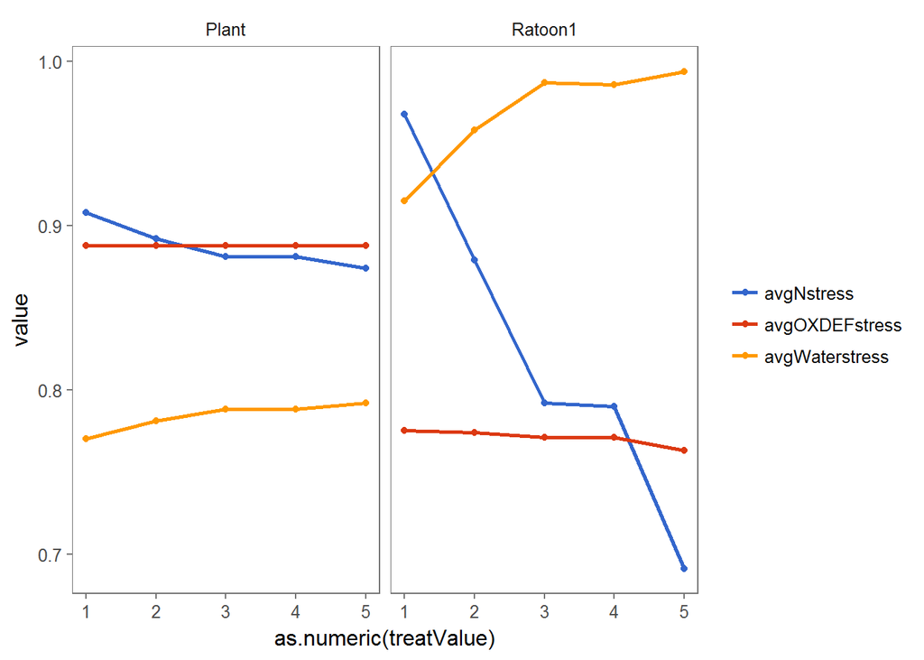

```r
#### Plot average stress indices ----
sim %>%
  select(treatCode, treatValue, ratoon_no, cropClass, avgNstress, avgWaterstress, avgOXDEFstress) %>%
  gather(variable, value, avgNstress, avgWaterstress, avgOXDEFstress) %>%
  ggplot(aes(as.numeric(treatValue), value, colour=variable))+
  geom_line(size=1)+
  geom_point()+
  scale_colour_gdocs()+
  facet_wrap(~cropClass)+
  theme_few()+
  theme(legend.title = element_blank())
```

## 2.2 Plot a partial N balance

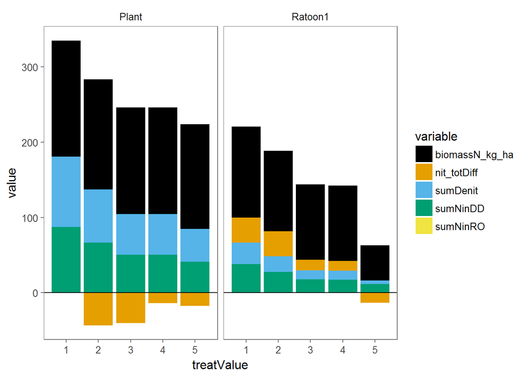

```r
initialTotN = head(sim$nit_tot..,1)

#### Plot a partial N balance ---
tmp <-
  sim %>%
  mutate(nit_totDiff = c(NA,diff(nit_tot..))) %>%
  # mutate(nit_totDiff = ifelse(ratoon_no == 0, NA, nit_totDiff)) %>%
  select(treatCode, treatValue, ratoon_no, cropClass, sumDenit, sumNinDD, sumNinRO, biomassN_kg_ha, nit_totDiff) %>%
  gather(variable, value, sumDenit, sumNinDD, sumNinRO, biomassN_kg_ha, nit_totDiff) %>%
  # mutate(variable = factor(variable, levels = c('sumDenit', 'sumNinDD', 'sumNinRO', 'biomassN_kg_ha', 'nit_totDiff'), labels = c('N denitrified', 'N in deep drainage', 'N in runoff', 'N in above ground biomass', 'Change in soil N'))) %>%
  mutate(treatValue = as.numeric(treatValue))

tmp1 <- tmp %>% filter(value >= 0)
tmp2 <- tmp %>% filter(value < 0)

ggplot()+
  geom_col(data=tmp1, aes(treatValue, value, fill = variable))+
  geom_col(data=tmp2, aes(treatValue, value, fill=variable))+
  geom_hline(yintercept=0)+
  scale_fill_colorblind()+
  facet_wrap(~cropClass)+
  theme_few()
```

## 2.3 Plot a partial water balance

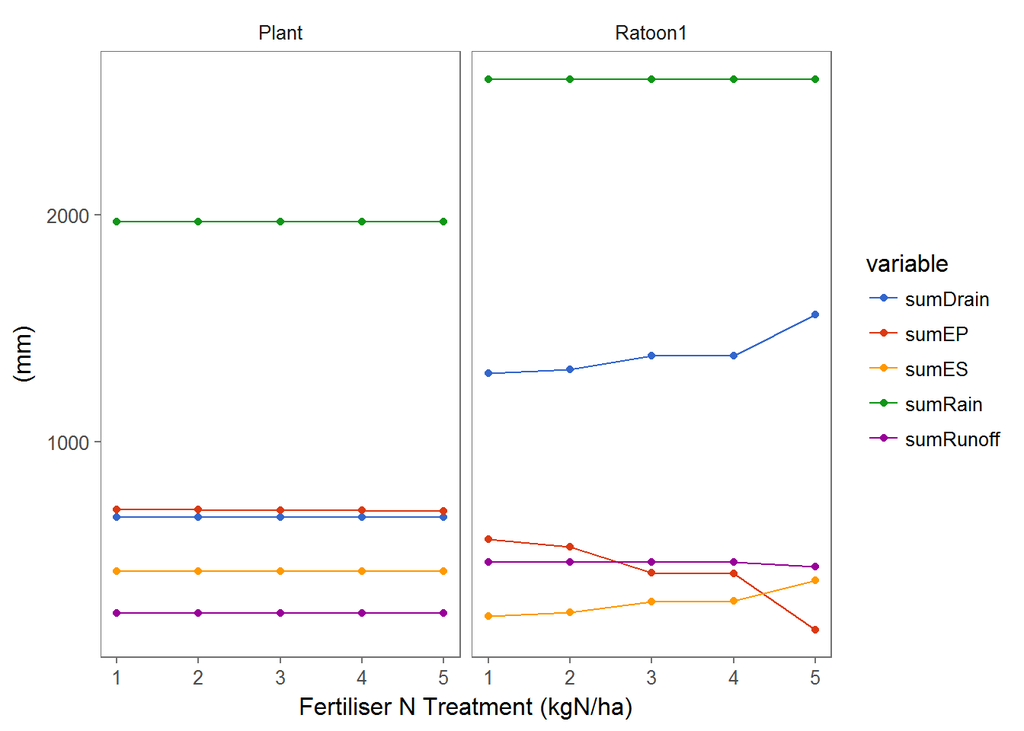

```r
#### Plot a partial water balance ----
sim %>%
  select(treatCode, treatValue, ratoon_no, cropClass, sumDrain, sumRunoff, sumRain, sumES, sumEP) %>%
  gather(variable, value, sumDrain, sumRunoff, sumRain, sumES, sumEP) %>%
  ggplot(aes(as.numeric(treatValue), value, colour=variable))+
  geom_line()+
  geom_point()+
  facet_wrap(~cropClass)+
  scale_colour_gdocs()+
  xlab('Fertiliser N Treatment (kgN/ha)')+
  ylab('(mm)')+
  theme_few()
```

# 3 Simulated vs Observed

## 3.1 Crop data

```r
#### Read in measured data ----
#### Cane yields ----
obsCrop <-
  read.csv('./Measurements/cropMeans.csv',
           header=TRUE, stringsAsFactors = FALSE) %>%
  tbl_df() %>%
  mutate(ratoon_no = as.character(ratoon_no)) %>%
  mutate(treatValue = str_sub(treatCode, 2,2)) %>%
  mutate(dataSource = 'measured') %>%
  select(treatCode, treatValue, ratoon_no, cropClass, dataSource, variable, value)

simCrop <-
  sim %>%
  select(treatCode, treatValue, ratoon_no, cropClass, yield_t_ha, biomass_kg_ha, biomassN_kg_ha, stem_N, leaf_N, cabb_N) %>%
  mutate(ratoon_no = as.character(ratoon_no)) %>%
  mutate(cropClass = as.character(cropClass)) %>%
  mutate(dataSource = 'simulated') %>%
  mutate(stemN_kg_ha = stem_N * 10) %>%
  mutate(topsN_kg_ha = (leaf_N * 10) + (cabb_N * 10)) %>%
  select(-stem_N, -leaf_N, -cabb_N) %>%
  gather(variable, value, yield_t_ha, biomass_kg_ha, biomassN_kg_ha, stemN_kg_ha, topsN_kg_ha)

d <-
  obsCrop %>%
  bind_rows(simCrop) %>%
  mutate(varDesc =
           factor(variable,
                  levels=c('biomass_kg_ha', 'biomassN_kg_ha', 'stemN_kg_ha', 'topsN_kg_ha', 'yield_t_ha'),
                  labels = c('Dry plant biomass(t/ha)', 'Biomass N (kg/ha)', 'Stem N (kg/ha)', 'Tops N (kg/ha)', 'Cane yield (t/ha)')))
```

- aboveground biomass appears to be measured but not reported.

### 3.1.1 Regression summary

```r
regrD  <-
  d %>%
  group_by(dataSource, treatCode, ratoon_no, cropClass, varDesc) %>%
  summarise(value = mean(value)) %>%
  spread(dataSource, value) %>%
  na.omit()

regrD_nested <-
  regrD %>%
  ungroup() %>%
  select(varDesc, measured, simulated) %>%
  nest(-varDesc)

fitLM <- function(x){lm(simulated ~ measured, data=x)}
gofd <- function(x){
  tmp <- gof(sim=x$simulated, obs=x$measured)
  data.frame(gofTest=row.names(tmp), tmp)
  }

model_nested <-
  regrD_nested %>%
  mutate(fit = map(data, fitLM)) %>%
  mutate(gof = map(data, gofd))

funcParam <-
  model_nested %>%
  rowwise() %>%
  do(params = glance(.$fit),
     formula = tidy(.$fit))

funcParam <-
  model_nested %>%
  bind_cols(funcParam)

kable(
  funcParam %>% unnest(formula)
)
```

| varDesc | term | estimate | std.error | statistic | p.value |
| --- | --- | --- | --- | --- | --- |
| Biomass N (kg/ha) | (Intercept) | 55.7619936 | 16.3095010 | 3.4189883 | 0.0091015 |
| Biomass N (kg/ha) | measured | 0.7874139 | 0.1864704 | 4.2227280 | 0.0029050 |
| Stem N (kg/ha) | (Intercept) | 42.5652068 | 10.3641359 | 4.1069711 | 0.0034048 |
| Stem N (kg/ha) | measured | 0.8134130 | 0.1785912 | 4.5546096 | 0.0018631 |
| Tops N (kg/ha) | (Intercept) | 19.6412253 | 7.2389373 | 2.7132747 | 0.0265233 |
| Tops N (kg/ha) | measured | 0.2535418 | 0.2405640 | 1.0539475 | 0.3226953 |
| Cane yield (t/ha) | (Intercept) | -3.1358963 | 20.5842422 | -0.1523445 | 0.8826873 |
| Cane yield (t/ha) | measured | 1.4599217 | 0.2582063 | 5.6540899 | 0.0004791 |

### 3.1.2 Model goodness-of-fit (gof)

```r
gofVariables <-
  model_nested %>%
  select(varDesc, gof) %>%
  unnest() %>%
  spread(varDesc, tmp)

kable(gofVariables)
```

| gofTest | Biomass N (kg/ha) | Stem N (kg/ha) | Tops N (kg/ha) | Cane yield (t/ha) |
| --- | --- | --- | --- | --- |
| bR2 | 0.50 | 0.49 | 0.11 | 0.56 |
| cp | 0.09 | -0.05 | 0.59 | -0.48 |
| d | 0.69 | 0.68 | 0.53 | 0.66 |
| KGE | 0.49 | 0.35 | 0.29 | 0.23 |
| MAE | 38.50 | 32.90 | 6.45 | 34.38 |
| md | 0.46 | 0.43 | 0.34 | 0.41 |
| ME | 38.50 | 32.90 | -2.23 | 32.32 |
| mNSE | -0.47 | -0.58 | -0.12 | -1.01 |
| MSE | 1823.90 | 1280.91 | 52.93 | 1350.91 |
| NRMSE % | 124.60 | 129.80 | 100.70 | 172.00 |
| NSE | -0.73 | -0.87 | -0.13 | -2.29 |
| PBIAS % | 47.40 | 63.50 | -7.60 | 41.90 |
| r | 0.83 | 0.85 | 0.35 | 0.89 |
| R2 | 0.69 | 0.72 | 0.12 | 0.80 |
| rd | 0.46 | 0.32 | 0.57 | 0.67 |
| RMSE | 42.71 | 35.79 | 7.28 | 36.75 |
| rNSE | -2.00 | -2.99 | -0.05 | -2.19 |
| rSD | 0.95 | 0.96 | 0.73 | 1.63 |
| RSR | 1.25 | 1.30 | 1.01 | 1.72 |
| VE | 0.53 | 0.36 | 0.78 | 0.55 |

### 3.1.3 Nitrogen response graphs

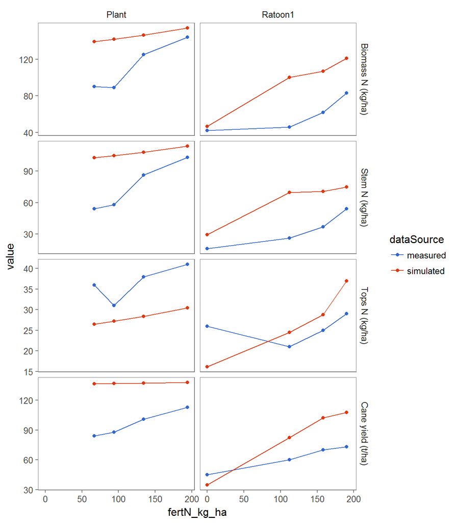

```r
regrD %>%
  filter(treatCode != 'T4') %>%
  gather(dataSource, value, measured, simulated) %>%
  left_join(treatDesc, by = c("treatCode", "ratoon_no")) %>%
  ggplot(aes(fertN_kg_ha, value, colour=dataSource))+
  geom_point()+
  geom_line()+
  facet_grid(varDesc~cropClass, scales='free_y')+
  scale_colour_gdocs()+
  theme_few()
```

### 3.1.4 X-Y plots

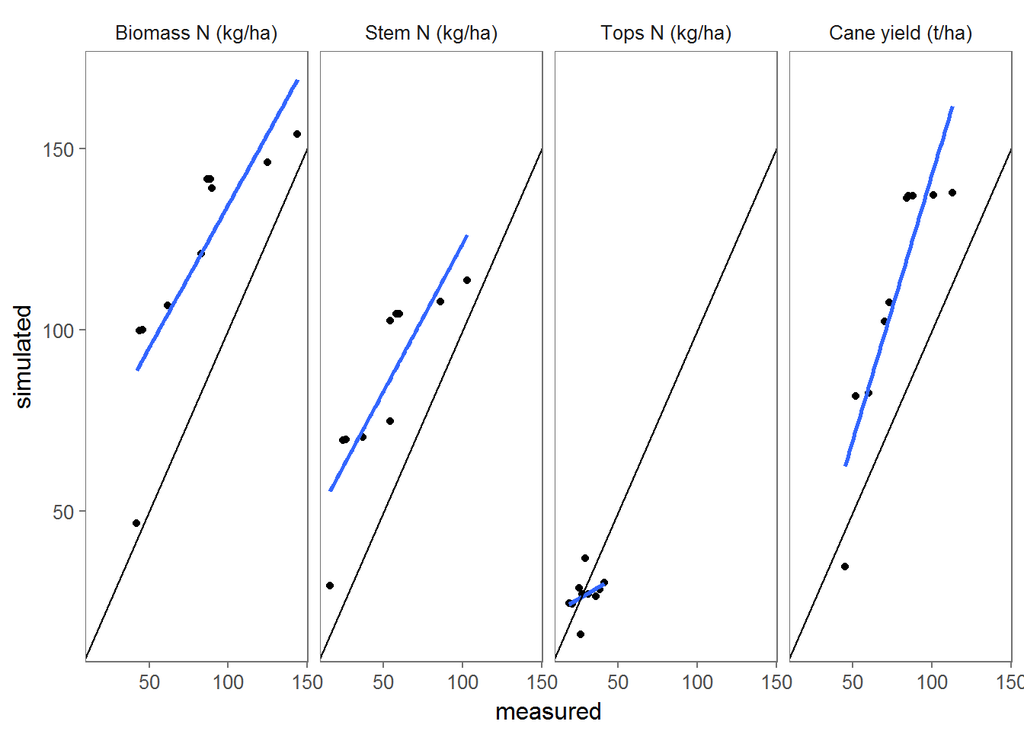

```r
regrD %>%
  left_join(treatDesc, by = c("treatCode", "ratoon_no")) %>%
  ggplot(aes(measured, simulated))+
  geom_point()+
  geom_smooth(method='lm', se=FALSE)+
  geom_abline()+
  scale_colour_gdocs()+
  facet_grid(~varDesc, scales='free_y')+
  theme_few()
```

## 3.2 Water data

```r
obsWater <-
  read.csv('./Measurements/waterBalance.csv', stringsAsFactors = FALSE) %>%
  tbl_df() %>%
  mutate(ratoon_no = as.character(ratoon_no)) %>%
  mutate(treatValue = str_sub(treatCode,2,2)) %>%
  mutate(dataSource = 'measured') %>%
  select(dataSource, treatCode, ratoon_no, cropClass, variable, value)

simWater <-
  sim %>%
  mutate(ratoon_no = as.character(ratoon_no),
         cropClass = as.character(cropClass),
         dataSource = 'simulated',
         cropRain_mm = sumRain,
         drainage_mm = sumDrain,
         evapotranspiration_mm = sumEP + sumES,
         runoff_mm = sumRunoff) %>%
  select(dataSource, treatCode, ratoon_no, cropClass, cropRain_mm, drainage_mm, evapotranspiration_mm, runoff_mm) %>%
  gather(variable, value, cropRain_mm, drainage_mm, evapotranspiration_mm, runoff_mm)

ddWater <-
  obsWater %>%
  bind_rows(simWater)
```

### 3.2.1 Regression summary

```r
regrD  <-
  ddWater %>%
  group_by(dataSource, treatCode, ratoon_no, cropClass, variable) %>%
  summarise(value = mean(value)) %>%
  spread(dataSource, value) %>%
  na.omit()

regrD_nested <-
  regrD %>%
  ungroup() %>%
  select(variable, measured, simulated) %>%
  nest(-variable)

fitLM <- function(x){lm(simulated ~ measured, data=x)}
gofd <- function(x){
  tmp <- gof(sim=x$simulated, obs=x$measured)
  data.frame(gofTest=row.names(tmp), tmp)
  }

model_nested <-
  regrD_nested %>%
  mutate(fit = map(data, fitLM)) %>%
  mutate(gof = map(data, gofd))

funcParam <-
  model_nested %>%
  rowwise() %>%
  do(params = glance(.$fit),
     formula = tidy(.$fit))
funcParam <-
  model_nested %>%
  bind_cols(funcParam)

kable(
  funcParam %>% unnest(formula)
)
```

| variable | term | estimate | std.error | statistic | p.value |
| --- | --- | --- | --- | --- | --- |
| cropRain_mm | (Intercept) | -2104.7506753 | 0.0000000 | -1.391364e+15 | 0.0000000 |
| cropRain_mm | measured | 2.0444805 | 0.0000000 | 2.909173e+15 | 0.0000000 |
| drainage_mm | (Intercept) | 2069.3085614 | 681.8174815 | 3.034989e+00 | 0.0229502 |
| drainage_mm | measured | -1.9160123 | 1.2109714 | -1.582211e+00 | 0.1646880 |
| evapotranspiration_mm | (Intercept) | 264.6098086 | 133.8257406 | 1.977271e+00 | 0.0953840 |
| evapotranspiration_mm | measured | 0.6740593 | 0.1288962 | 5.229473e+00 | 0.0019582 |
| runoff_mm | (Intercept) | 215.9798654 | 22.8192515 | 9.464809e+00 | 0.0000792 |
| runoff_mm | measured | 0.2416773 | 0.0309673 | 7.804283e+00 | 0.0002334 |

### 3.2.2 Model goodness-of-fit (gof)

```r
gofVariables <-
  model_nested %>%
  select(variable, gof) %>%
  unnest() %>%
  spread(variable, tmp)

kable(gofVariables)
```

| gofTest | cropRain_mm | drainage_mm | evapotranspiration_mm | runoff_mm |
| --- | --- | --- | --- | --- |
| bR2 | 0.94 | 0.17 | 0.76 | 0.43 |
| cp | 0.46 | -15.52 | 0.96 | 0.72 |
| d | 0.81 | 0.08 | 0.91 | 0.63 |
| KGE | -0.05 | -2.07 | 0.72 | 0.16 |
| MAE | 160.85 | 461.76 | 98.17 | 321.03 |
| md | 0.66 | 0.13 | 0.76 | 0.51 |
| ME | 137.75 | 451.65 | -63.49 | -228.11 |
| mNSE | -0.04 | -4.80 | 0.56 | 0.25 |
| MSE | 44847.51 | 364189.36 | 17345.36 | 168220.14 |
| NRMSE % | 128.60 | 586.70 | 48.40 | 85.80 |
| NSE | -0.89 | -38.33 | 0.73 | 0.16 |
| PBIAS % | 6.40 | 81.40 | -6.30 | -39.00 |
| r | 1.00 | -0.54 | 0.91 | 0.95 |
| R2 | 1.00 | 0.29 | 0.82 | 0.91 |
| rd | 0.84 | -0.33 | 0.94 | 0.04 |
| RMSE | 211.77 | 603.48 | 131.70 | 410.15 |
| rNSE | -0.65 | -56.05 | 0.81 | -1.20 |
| rSD | 2.04 | 3.53 | 0.74 | 0.25 |
| RSR | 1.29 | 5.87 | 0.48 | 0.86 |
| VE | 0.93 | 0.17 | 0.90 | 0.45 |

### 3.2.3 Nitrogen response graphs

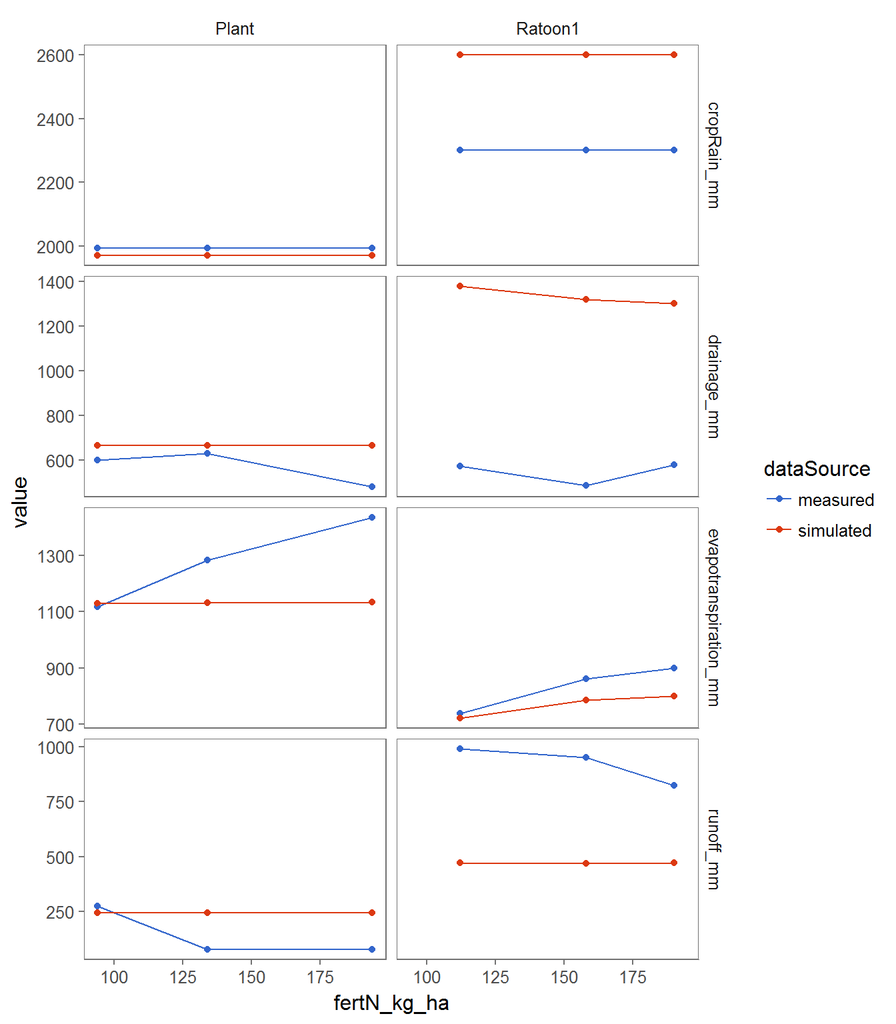

```r
regrD %>%
  filter(treatCode != 'T4') %>%
  gather(dataSource, value, measured, simulated) %>%
  left_join(treatDesc, by = c("treatCode", "ratoon_no")) %>%
  ggplot(aes(fertN_kg_ha, value, colour=dataSource))+
  geom_point()+
  geom_line()+
  facet_grid(variable~cropClass, scales='free_y')+
  scale_colour_gdocs()+
  theme_few()
```

### 3.2.4 X-Y plots

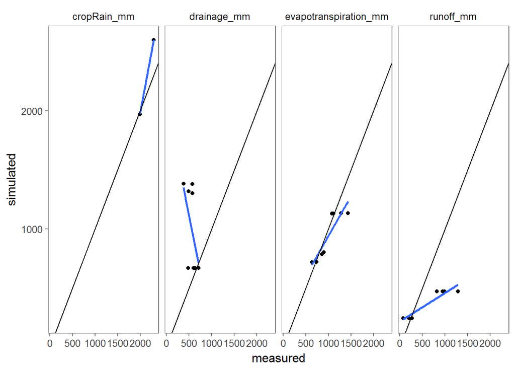

```r
regrD %>%
  left_join(treatDesc, by = c("treatCode", "ratoon_no")) %>%
  ggplot(aes(measured, simulated))+
  geom_point()+
  geom_smooth(method='lm', se=FALSE)+
  geom_abline()+
  scale_colour_gdocs()+
  facet_grid(~variable, scales='free_y')+
  theme_few()
```

# 4 Further Analysis (incl OptN)

## 4.1 Determine the N rate/s where 95% of yield at maximum N was achieved

```r
#### Determine the N rate/s where 95% of yield at maximum N was achieved ----

d1 <-
  d %>%
  filter(variable == 'yield_t_ha') %>%
  group_by(dataSource, ratoon_no, treatCode, variable) %>%
  summarise(meanYld = mean(value))

n240Values <-
  d1 %>%
  filter(treatCode == 'T1') %>%
  mutate(AtMaxN = meanYld) %>%
  ungroup() %>%
  select(-treatCode, -meanYld)

d1 <-
  d1 %>%
  left_join(n240Values, by = c("dataSource", "ratoon_no", "variable")) %>%
  mutate(percOfMaxN = meanYld/AtMaxN * 100)

kable(d1)
```

| dataSource | ratoon_no | treatCode | variable | meanYld | AtMaxN | percOfMaxN |
| --- | --- | --- | --- | --- | --- | --- |
| measured | 0 | T1 | yield_t_ha | 113.00000 | 113.0000 | 100.00000 |
| measured | 0 | T2 | yield_t_ha | 101.00000 | 113.0000 | 89.38053 |
| measured | 0 | T3 | yield_t_ha | 88.00000 | 113.0000 | 77.87611 |
| measured | 0 | T4 | yield_t_ha | 85.00000 | 113.0000 | 75.22124 |
| measured | 0 | T5 | yield_t_ha | 84.00000 | 113.0000 | 74.33628 |
| measured | 1 | T1 | yield_t_ha | 73.00000 | 73.0000 | 100.00000 |
| measured | 1 | T2 | yield_t_ha | 70.00000 | 73.0000 | 95.89041 |
| measured | 1 | T3 | yield_t_ha | 60.00000 | 73.0000 | 82.19178 |
| measured | 1 | T4 | yield_t_ha | 52.00000 | 73.0000 | 71.23288 |
| measured | 1 | T5 | yield_t_ha | 45.00000 | 73.0000 | 61.64384 |
| simulated | 0 | T1 | yield_t_ha | 137.77833 | 137.7783 | 100.00000 |
| simulated | 0 | T2 | yield_t_ha | 137.26700 | 137.7783 | 99.62887 |
| simulated | 0 | T3 | yield_t_ha | 136.92300 | 137.7783 | 99.37920 |
| simulated | 0 | T4 | yield_t_ha | 136.92300 | 137.7783 | 99.37920 |
| simulated | 0 | T5 | yield_t_ha | 136.44800 | 137.7783 | 99.03444 |
| simulated | 1 | T1 | yield_t_ha | 107.58233 | 107.5823 | 100.00000 |
| simulated | 1 | T2 | yield_t_ha | 102.39033 | 107.5823 | 95.17393 |
| simulated | 1 | T3 | yield_t_ha | 82.53367 | 107.5823 | 76.71675 |
| simulated | 1 | T4 | yield_t_ha | 81.68133 | 107.5823 | 75.92449 |
| simulated | 1 | T5 | yield_t_ha | 34.71367 | 107.5823 | 32.26707 |